# Презентация

по лабораторной работе № 4

Зинченко А.Р

Российский университет дружбы народов, Москва, Россия

09.03.2024

# Информация

## Докладчик

- Зинченко Анастасия Романовна
- Российский университет дружбы народов

# Цель работы

Получить навыки правильной раюоты с репозиториями git

# Задание

1. Установка программного обеспечения
2. Установка git-flow
3. Установка Node.js
4. Настройка Node.js
5. Общепринятые коммиты

# Выполнение лабораторной работы

Установила nodejs и pnpm, с помощью команд dnf install nodejs и dnf install pnpm (рис. [-@fig:001]).

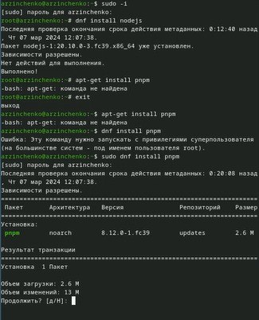

Установка nodejs и pnpm

Запустила pnpm setup (рис. [-@fig:002]).

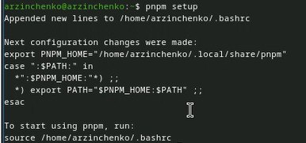

pnpm setup

## Выполнение лабораторной работы

Выполнила source ~/.bashrc (рис. [-@fig:003]).

[figure not shown]

source ~/.bashrc

Сформатировала коммиты с помощью команды рnpm add -g commitizen (рис. [-@fig:004]).

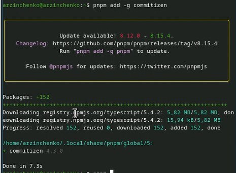

Форматирование коммитов

## Выполнение лабораторной работы

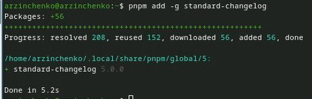

standard-changelog

Создала репозиторий на GitHub и назвала его git-extended (рис. [-@fig:006]).

[figure not shown]

Создание репозитория

## Выполнение лабораторной работы

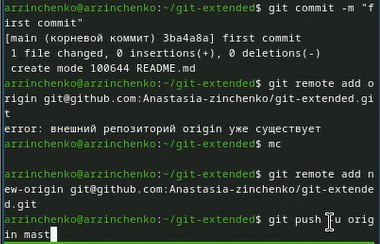

Первый коммит

Изменила файл package.json (рис. [-@fig:008]).

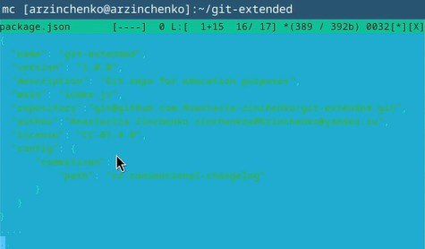

Изменённый файл package.json

## Выполнение лабораторной работы

Выполнила коммит с помощью команды git cz (рис. [-@fig:010]).

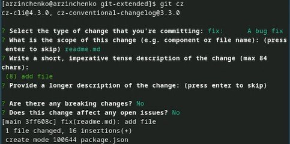

Коммит

## Выполнение лабораторной работы

Инициализировала git-flow с помощью команды git flow init (рис. [-@fig:011]).

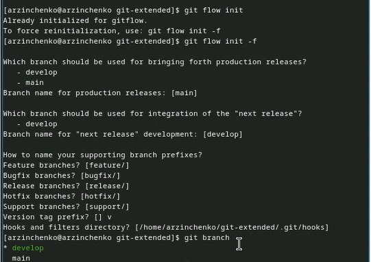

Инициализация

Проверила, что я на ветке develop с помощью команды git branch (рис. [-@fig:012]).

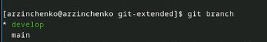

Проверка

## Выполнение лабораторной работы

Загрузила весь репозиторий в хранилище с помощью команды git push –all (рис. [-@fig:013]).

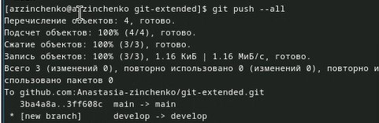

Загрузка репозитория в хранилище

Установила внешнюю ветку как вышестоящую для этой ветки с помощью команды git branch –set-upstream-to=origin/develop develop (рис. [-@fig:014]).

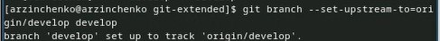

Установка ветки

## Выполнение лабораторной работы

Создала релиз с версией 1.0.0 с помощью команды git flow release start 1.0.0 (рис. [-@fig:015]).

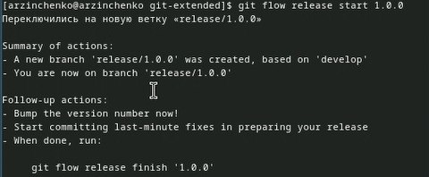

Создание релиза

Создала журнал изменений с помощью команды standard-changelog –first-release (рис. [-@fig:016]).

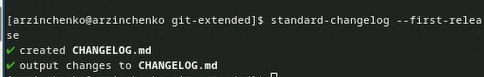

Создание журнала

## Выполнение лабораторной работы

Добавила журнал изменений в индекс с помощью команд git add CHANGELOG.md и git commit -am ‘chore(site): add changelog’ (рис. [-@fig:017]).

[figure not shown]

Добавление журнала

Залила релизную ветку в основную ветку с помощью команды git flow release finish 1.0.0 (рис. [-@fig:018]).

[figure not shown]

Релизная ветка в основную

## Выполнение лабораторной работы

Отправила данные на github с помощью команд git push –all и git push –tags (рис. [-@fig:019).

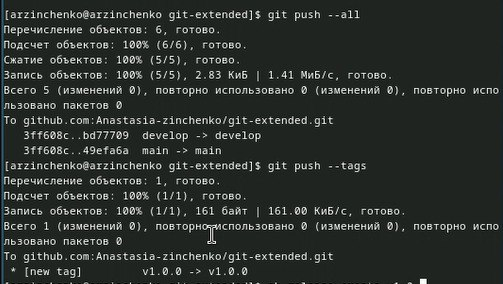

Отправка данных

Создала релиз на github. Для этого использовала утилиты работы с github: gh release create v1.0.0 -F CHANGELOG.md (рис. [-@fig:020]).

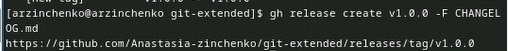

Создание релиза

## Выполнение лабораторной работы

Создала ветку для новой функциональности с помощью команды git flow feature start feature_branch (рис. [-@fig:021]).

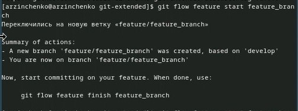

Создание ветки

Объединила ветку feature_branch c develop с помощью команды git flow feature finish feature_branch (рис. [-@fig:022]).

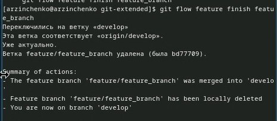

Объединила ветки

## Выполнение лабораторной работы

Создала релиз с версией 1.2.3 с помощью команды git flow release start 1.2.3 (рис. [-@fig:023]).

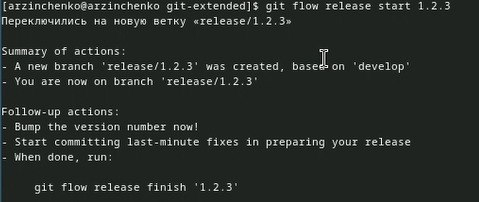

Создание релиза

## Выполнение лабораторной работы

Создадала журнал изменений с помощью команды standard-changelog (рис. [-@fig:024]).

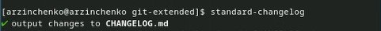

Создание журнала изменений

Добавила журнал изменений в индекс с помощью команд git add CHANGELOG.md git commit -am ‘chore(site): update changelog’ (рис. [-@fig:025]).

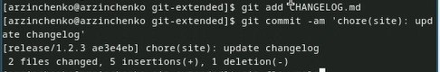

Добавление журнала изменений

## Выполнение лабораторной работы

Залила релизную ветку в основную ветку с помощью команды git flow release finish 1.2.3 (рис. [-@fig:026]).

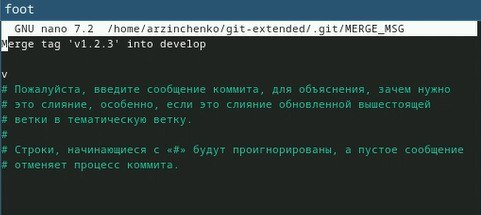

Релизная ветка в основную

Отправила данные на github с помощью команд git push –all git push –tags (рис. [-@fig:027]).

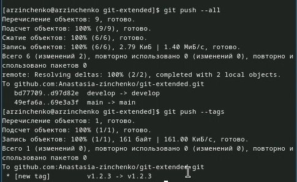

Отправка данных

## Выполнение лабораторной работы

Создадала релиз на github с комментарием из журнала изменений с помощью команды gh release create v1.2.3 -F CHANGELOG.md (рис. [-@fig:028]).

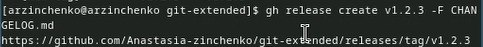

Создание релиза

# Выводы

Я получила навыки правильной работы с репозиториями git

# Список литературы